# Select Topics in R Programming - Part I

Joong-Ho Won

December 03, 2018

## Acknowledgment

This lecture note is based on [Dr. Hua Zhou](http://hua-zhou.github.io)’s 2018 Winter Statistical Computing course notes available at http://hua-zhou.github.io/teaching/biostatm280-2018winter/index.html.

## *Advanced R*

To gain a deep understanding of how R works, the book [Advanced R](http://adv-r.had.co.nz) by Hadley Wickham is a must read. Read **now** to save numerous hours you might waste in future.

We cover select topics on coding style, benchmarking, profiling, debugging, parallel computing, byte code compiling, Rcpp, and package development.

## Style

- [Google’s R style](https://google.github.io/styleguide/Rguide.xml).
- [Hadley Wickham’s style guide](http://adv-r.had.co.nz/Style.html).
- Most important is to be consistent in your code style.

## Benchmark

Sources:  
- *Advanced R*: http://adv-r.had.co.nz/Performance.html  
- Blog: http://www.alexejgossmann.com/benchmarking_r/

In order to identify performance issue, we need to measure runtime accurately.

### `system.time`

```r
set.seed(280)
x <- runif(1e6)

system.time({sqrt(x)})
```

```
##    user  system elapsed
##   0.010   0.003   0.014
```

```r
system.time({x ^ 0.5})
```

```
##    user  system elapsed
##   0.039   0.001   0.041
```

```r
system.time({exp(log(x) / 2)})
```

```
##    user  system elapsed
##   0.024   0.000   0.025
```

From [William Dunlap](http://r.789695.n4.nabble.com/Meaning-of-proc-time-td2303263.html#a2306691):

> “User CPU time” gives the CPU time spent by the current process (i.e., the current R session) and “system CPU time” gives the CPU time spent by the kernel (the operating system) on behalf of the current process. The operating system is used for things like opening files, doing input or output, starting other processes, and looking at the system clock: operations that involve resources that many processes must share. Different operating systems will have different things done by the operating system.

### `rbenchmark`

```r
library("rbenchmark")

benchmark(
  "sqrt(x)" = {sqrt(x)},
  "x^0.5" = {x ^ 0.5},
  "exp(log(x)/2)" = {exp(log(x) / 2)},
  replications = 100,
  order = "elapsed"
)
```

```
##            test replications elapsed relative user.self sys.self user.child sys.child
## 1       sqrt(x)          100   0.490    1.000     0.355    0.134          0         0
## 3 exp(log(x)/2)          100   1.952    3.984     1.813    0.128          0         0
## 2         x^0.5          100   2.870    5.857     2.705    0.142          0         0
```

`relative` is the ratio with the fastest one.

### `microbenchmark`

```r
library("microbenchmark")
library("ggplot2")

mbm <- microbenchmark(
  sqrt(x),
  x ^ 0.5,
  exp(log(x) / 2)
)
mbm
```

```
## Unit: milliseconds
##           expr       min        lq     mean    median       uq      max neval
##        sqrt(x)  2.163406  3.269818  4.06793  3.449744  3.62813 11.53134   100
##          x^0.5 23.911824 25.512446 27.57804 26.592014 29.06186 36.20914   100
##  exp(log(x)/2) 15.983428 17.290515 19.10205 18.008370 19.31630 28.99174   100
```

Results from `microbenchmark` can be nicely plotted in base R or ggplot2.

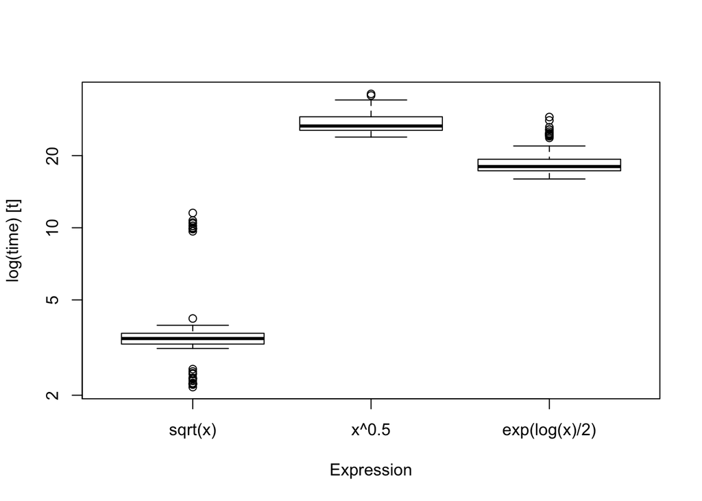

```r
boxplot(mbm)
```

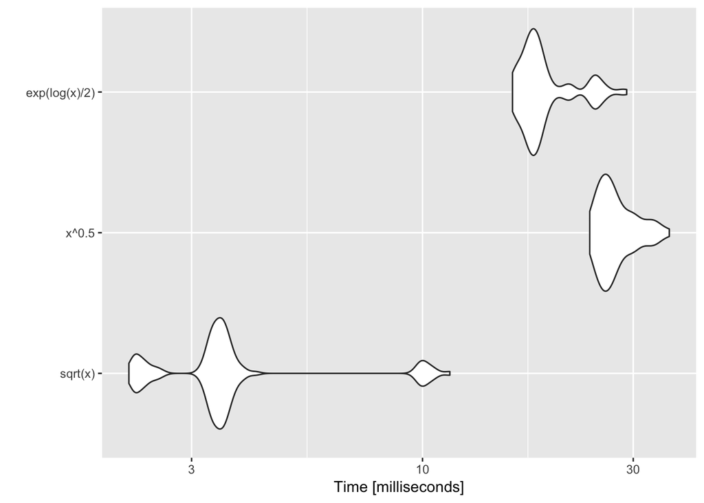

```r
autoplot(mbm)
```

## Profiling

> Premature optimization is the root of all evil (or at least most of it) in programming.  
> -Don Knuth

Sources: - http://adv-r.had.co.nz/Profiling.html  
- https://rstudio.github.io/profvis/  
- https://support.rstudio.com/hc/en-us/articles/218221837-Profiling-with-RStudio

### First example

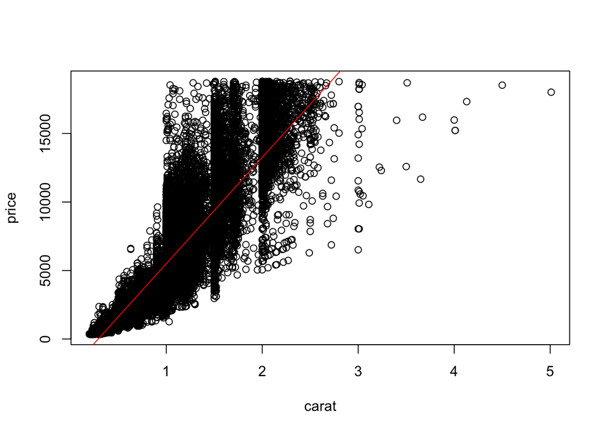

[interactive chart not shown]

```r
library(profvis)

profvis({
  data(diamonds, package = "ggplot2")

  plot(price ~ carat, data = diamonds)
  m <- lm(price ~ carat, data = diamonds)
  abline(m, col = "red")
})
```

### Example: profiling time

First generate test data:

```r
times <- 4e5
cols <- 150
data <-
  as.data.frame(x = matrix(rnorm(times * cols, mean = 5),
                           ncol = cols))
data <- cbind(id = paste0("g", seq_len(times)), data)
```

Original code for centering columns of a dataframe:

```r
profvis({
  # Store in another variable for this run
  data1 <- data

  # Get column means
  means <- apply(data1[, names(data1) != "id"], 2, mean)

  # Subtract mean from each column
  for (i in seq_along(means)) {
    data1[, names(data1) != "id"][, i] <-
      data1[, names(data1) != "id"][, i] - means[i]
  }
})
```

[interactive chart not shown]

Profile `apply` vs `colMeans` vs `lapply` vs `vapply`:

```r
profvis({
  data1 <- data
  # Four different ways of getting column means
  means <- apply(data1[, names(data1) != "id"], 2, mean)
  means <- colMeans(data1[, names(data1) != "id"])
  means <- lapply(data1[, names(data1) != "id"], mean)
  means <- vapply(data1[, names(data1) != "id"], mean, numeric(1))
})
```

[interactive chart not shown]

We decide to use `vapply`:

```r
profvis({
  data1 <- data
  means <- vapply(data1[, names(data1) != "id"], mean, numeric(1))

  for (i in seq_along(means)) {
    data1[, names(data1) != "id"][, i] <- data1[, names(data1) != "id"][, i] - means[i]
  }
})
```

[interactive chart not shown]

Calculate mean and center in one pass:

```r
profvis({
 data1 <- data

 # Given a column, normalize values and return them
 col_norm <- function(col) {
 col - mean(col)
 }

 # Apply the normalizer function over all columns except id
 data1[, names(data1) != "id"] <-
   lapply(data1[, names(data1) != "id"], col_norm)
})
```

[interactive chart not shown]

### Example: profiling memory

Original code for cumulative sums:

```r
profvis({
  data <- data.frame(value = runif(1e5))

  data$sum[1] <- data$value[1]
  for (i in seq(2, nrow(data))) {
    data$sum[i] <- data$sum[i-1] + data$value[i]
  }
})
```

[interactive chart not shown]

Write a function to avoid expensive indexing by `$`:

```r
profvis({
  csum <- function(x) {
    if (length(x) < 2) return(x)

    sum <- x[1]
    for (i in seq(2, length(x))) {
      sum[i] <- sum[i-1] + x[i]
    }
    sum
  }
  data$sum <- csum(data$value)
})
```

[interactive chart not shown]

Pre-allocate vector:

```r
profvis({
  csum2 <- function(x) {
    if (length(x) < 2) return(x)

    sum <- numeric(length(x))  # Preallocate
    sum[1] <- x[1]
    for (i in seq(2, length(x))) {
      sum[i] <- sum[i-1] + x[i]
    }
    sum
  }
  data$sum <- csum2(data$value)
})
```

[interactive chart not shown]

### Advice

Modularize big projects into small functions. Profile functions as early and as frequently as possible.

## Debugging

Learning sources:  
- Video: https://vimeo.com/99375765  
- *Advanced R*: http://adv-r.had.co.nz/Exceptions-Debugging.html  
- RStudio tutorial: https://support.rstudio.com/hc/en-us/articles/205612627-Debugging-with-RStudio

Key concepts:

- breakpoint
- step in/through function
- `browser()`
- `traceback()`
- `options(error = browser)`, `options(error = NULL)`, `Debug` -> `On Error` -> `Break in Code`